# Gentrification Predictive Modeling in Philadelphia

#### 2.3.4 Food Access

In Philadelphia, the food access landscape between 2014 and 2019 shows distinct changes that are crucial in understanding neighborhood dynamics related to gentrification. Improved access to healthy food can signal gentrification as newer, wealthier demographics move in, leading to shifts in local markets and food retailers to cater to these new residents. Analyzing changes in food access helps us assess whether areas are becoming more gentrified and possibly identify the socio-economic shifts accompanying this transformation. In our analysis, we processed GeoJSON files for 2014 and 2019 to quantify food access. Each file was read and transformed to categorize levels of access into numerical values, representing no, low, moderate, and high access. We computed the centroids of these spatial points to facilitate joining with the census tract data (PHLCensus). By aggregating the transformed food access data by census tract, we computed the mean access levels for both years, ensuring continuity in our spatial analysis despite potential missing values by replacing them with the mean access level. This method allows us to track changes in food access over time, aligning with shifts in demographic and economic indicators within the census tracts.

```r
food_2019 <- st_read("Food_access/NeighborhoodFoodRetail.geojson") %>%
  mutate(HPSS_ACCESS_t2 = ifelse(HPSS_ACCESS == "No Access", 0,
  ifelse(HPSS_ACCESS == "Low Access", 1, 2))) %>%
  select("HPSS_ACCESS_t2")

# Calculate mean of column A (ignoring NAs)
mean_A <- mean(food_2019$HPSS_ACCESS_t2, na.rm = TRUE)

# Replace NA values in column A with the mean
food_2019$HPSS_ACCESS_t2[is.na(food_2019$HPSS_ACCESS_t2)] <- mean_A

food_2019 <- st_centroid(food_2019)

Access_census_2019 <- PHLCensus %>%
  st_join(., food_2019) %>%
  group_by(GEOID) %>%
  summarise(Access_t2 = mean(HPSS_ACCESS_t2)) %>%
  st_drop_geometry()


food_2014 <- st_read("Food_access/Walkable_Access_Healthy_Food.geojson") %>%
  mutate(HPSS_ACCESS_t1 = ifelse(ACCESS_ == "No Access", 0,
  ifelse(ACCESS_ == "Low Access", 1,
  ifelse(ACCESS_ == "Moderate Access", 2, 3)))) %>%
  select("HPSS_ACCESS_t1")

food_2014 <- st_make_valid(food_2014)

# mapview(food_2014)

food_2014 <- st_centroid(food_2014)
# Calculate mean of column A (ignoring NAs)
mean_B <- mean(food_2019$HPSS_ACCESS_t2, na.rm = TRUE)

# Replace NA values in column A with the mean
food_2014$HPSS_ACCESS_t1[is.na(food_2014$HPSS_ACCESS_t1)] <- mean_B

Access_census_2014 <- PHLCensus %>%
  st_join(., food_2014) %>%
  group_by(GEOID) %>%
  summarise(Access_t1 = mean(HPSS_ACCESS_t1)) %>%
  st_drop_geometry()

PHLCensus <- PHLCensus %>%
  left_join(., Access_census_2014) %>%
  left_join(., Access_census_2019)
```

#### 2.3.5 Bus Stops

```r
bus_2014 <- read_csv("Bus_Ridership_by_Census_Tract_2014.csv") %>%
  filter(Season == "Fall 2014") %>%
  group_by(Census_Tract_ID) %>%
  summarise(Total_On_t1 = sum(On_)) %>%
  select("Total_On_t1", "Census_Tract_ID")%>%
  rename(GEOID = Census_Tract_ID)

bus_2014$GEOID <- as.character(bus_2014$GEOID)

bus_2019 <- read_csv("Bus_Ridership_by_Census_Tract_2019.csv") %>%
  filter(Season == "Fall 2019") %>%
  group_by(Census_Tract_ID) %>%
  summarise(Total_On_t2 = sum(On_)) %>%
  select("Total_On_t2", "Census_Tract_ID") %>%
  rename(GEOID = Census_Tract_ID)
bus_2019$GEOID <- as.character(bus_2019$GEOID)

PHLCensus_Bus_2014 <- PHLCensus %>%
  left_join(., bus_2014, by = c("GEOID"))

PHLCensus <- PHLCensus_Bus_2014 %>%
  left_join(., bus_2019, by = c("GEOID"))
```

#### 2.3.5 Crime

To analyze crime data, we utilized incident reports from 2014 and 2019. The process involved: - Reading spatial data for crime incidents from these years, - Selecting relevant attributes, and - Transforming them to match the Coordinate Reference System (CRS) of the PHLCensus data.

We then performed a spatial join of the crime data with the PHLCensus tracts, grouping by GEOID to calculate the total number of crimes reported in each tract for both years. This method allowed us to observe changes in crime rates across the census tracts, providing insights into the safety and livability of neighborhoods, which are crucial factors in gentrification studies.

```r
crime_2014 <- st_read("crime2014/incidents_part1_part2.shp") %>%
  select("objectid")

crime_2014 <- st_transform(crime_2014, crs = PHLCensus_crs)

crime_2019 <- st_read("crime2019/incidents_part1_part2.shp") %>%
  select("objectid")

crime_2019 <- st_transform(crime_2019, crs = PHLCensus_crs)

crime_count_2014 <- PHLCensus %>%
  st_join(., crime_2014) %>%
  group_by(GEOID) %>%
  summarise(crime_count_2014 = n()) %>%
  st_drop_geometry()

crime_count_2019 <- PHLCensus %>%
  st_join(., crime_2019) %>%
  group_by(GEOID) %>%
  summarise(crime_count_2019 = n()) %>%
  st_drop_geometry()

PHLCensus <- PHLCensus %>%
  left_join(., crime_count_2014) %>%
  left_join(., crime_count_2019)
```

## 4 Modeling

### 4.1 Model Development

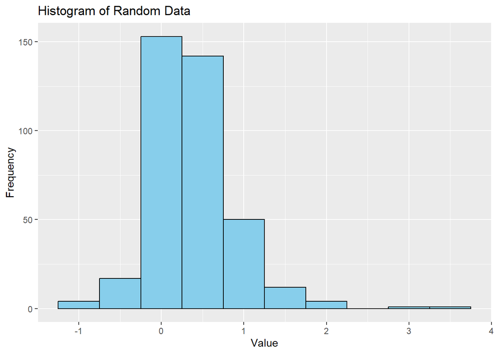

```r
PHLCensus <- PHLCensus %>%
  mutate(park_change = (total_parks_t2 - total_parks_t1)/total_parks_t1,
         bus_change = (Total_On_t2 - Total_On_t1)/Total_On_t1,
         permits_change = (num_permits_t2 - num_permits_t1)/num_permits_t1,
         food_change = (Access_t2 - Access_t1)/Access_t1,
         school_change = (school_count_2019 - school_count_2014)/school_count_2014,
         crime_change = (crime_count_2019 - crime_count_2014)/crime_count_2014)

PHLCensus <- PHLCensus[complete.cases(PHLCensus$gent_score), ]

PHLCensus <- transform(PHLCensus,
                       permits_change = ifelse(is.na(permits_change), mean(permits_change, na.rm = TRUE), permits_change),
                       food_change = ifelse(is.na(food_change), mean(food_change, na.rm = TRUE), food_change),
                       school_change = ifelse(is.na(school_change), mean(school_change, na.rm = TRUE), school_change),
                       crime_change = ifelse(is.na(crime_change), mean(crime_change, na.rm = TRUE), crime_change),
                       change_high_income = ifelse(is.na(change_high_income), mean(change_high_income, na.rm = TRUE), change_high_income))

#PHLCensus <- PHLCensus %>%
#  filter(cate_gent == "gentrified" | cate_gent == "highly gentrified")
# Fit the linear regression model


model.2 <- lm(gent_score ~ num_permits_t2 +  total_parks_t2 + school_count_2019 +
              crime_count_2019 +  Med_Age_t2, data = PHLCensus)

#summary(model)
summary(model.2)

ggplot(data = PHLCensus, aes(x = gent_score)) +
  geom_histogram(binwidth = 0.5, fill = "skyblue", color = "black") +
  labs(title = "Histogram of Random Data", x = "Value", y = "Frequency")
```

[output not shown]

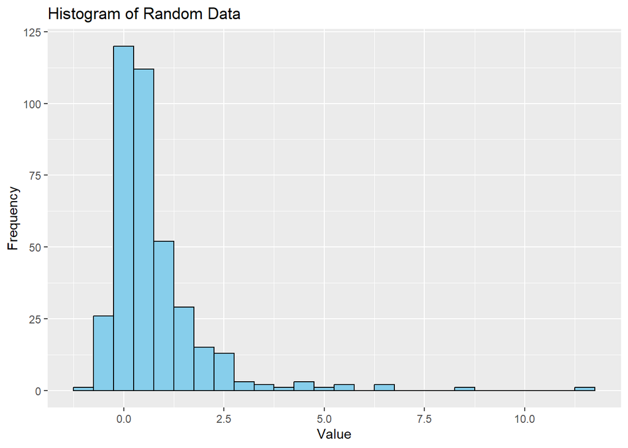

```r
ggplot(data = PHLCensus, aes(x = permits_change)) +
  geom_histogram(binwidth = 0.5, fill = "skyblue", color = "black") +
  labs(title = "Histogram of Random Data", x = "Value", y = "Frequency")
```

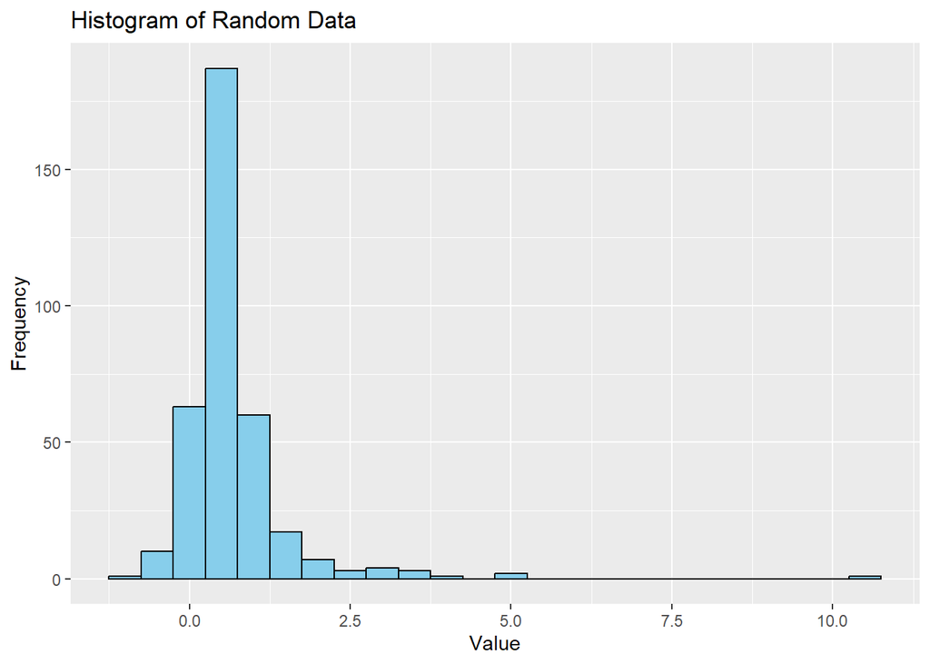

```r
ggplot(data = PHLCensus, aes(x = bus_change)) +
  geom_histogram(binwidth = 0.5, fill = "skyblue", color = "black") +
  labs(title = "Histogram of Random Data", x = "Value", y = "Frequency")
```

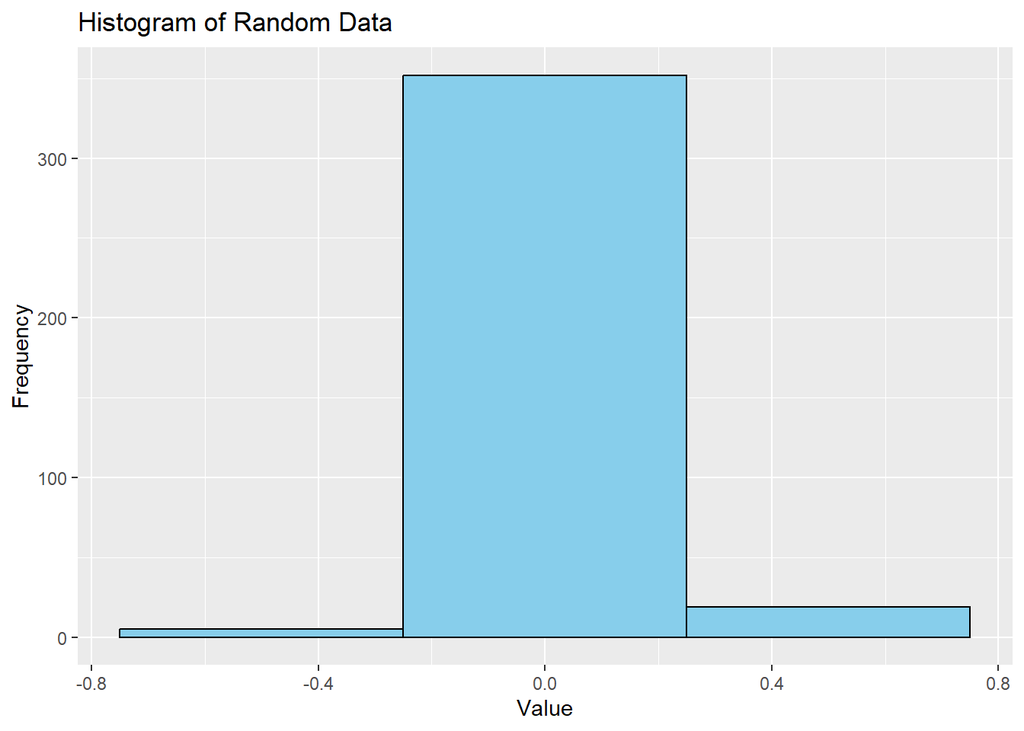

```r
ggplot(data = PHLCensus, aes(x = change_age)) +
  geom_histogram(binwidth = 0.5, fill = "skyblue", color = "black") +
  labs(title = "Histogram of Random Data", x = "Value", y = "Frequency")
```

### 4.2 Model Testing and Validation

```r
PHLCensus_2022 <-
  get_acs(geography = "tract",
          variables = c("B01003_001E", "B19013_001E",
                        "B01002_001E", "B02001_002E",
                        "B23006_023E", "B08301_001E", "B08301_010E"),
          year = 2022,
          state = "PA",
          county = "Philadelphia",
          geometry = TRUE,
          output = "wide") %>%
  rename(Total_Pop_t1 =  B01003_001E,
         Med_Inc_t1 = B19013_001E,
         Med_Age_t1 = B01002_001E,
         Black_Pop_t1 = B02001_002E,
         Education_attainment_t1 = B23006_023E,
         Median_rent_t1 = B08301_001E,
         Total_Public_Trans_t1 = B08301_010E) %>%
  select(Total_Pop_t1, Med_Inc_t1, Black_Pop_t1, Education_attainment_t1,
         Total_Public_Trans_t1, Med_Age_t1, Median_rent_t1,
         GEOID, geometry) %>%
  mutate(Percent_black_t1 = Black_Pop_t1 / Total_Pop_t1) %>%
  st_transform(crs = "EPSG:4326") %>%
  select(Med_Inc_2022 = Med_Inc_t1, Med_rent_2022 = Median_rent_t1)

centroids_2022 <- st_centroid(PHLCensus_2022)

PHLCensus_2022_combined <- PHLCensus %>%
  st_join(., centroids_2022) %>%
  group_by(GEOID) %>%
  summarise(Med_Inc_2022 = mean(Med_Inc_2022), Med_rent_2022 = mean(Med_rent_2022)) %>%
  st_drop_geometry()

mean_inc <- mean(PHLCensus_2022_combined$Med_Inc_2022, na.rm = TRUE)

mean_rent <- mean(PHLCensus_2022_combined$Med_rent_2022, na.rm = TRUE)

# Replace NA values with the mean
PHLCensus_2022_combined$Med_Inc_2022 <- ifelse(is.na(PHLCensus_2022_combined$Med_Inc_2022), mean_inc, PHLCensus_2022_combined$Med_Inc_2022)

PHLCensus_2022_combined$Med_rent_2022 <- ifelse(is.na(PHLCensus_2022_combined$Med_rent_2022), mean_rent, PHLCensus_2022_combined$Med_rent_2022)

mean_rent <- mean(PHLCensus_2022_combined$Med_rent_2022[PHLCensus_2022_combined$Med_rent_2022 != 0])

# Replace 0 values with the mean
PHLCensus_2022_combined$Med_rent_2022 <- ifelse(PHLCensus_2022_combined$Med_rent_2022 == 0, mean_rent, PHLCensus_2022_combined$Med_rent_2022)

PHLCensus <- PHLCensus %>%
  left_join(., PHLCensus_2022_combined)

PHLCensus <- PHLCensus %>%
  mutate(gent_score_2022 = (Med_rent_2022 - Median_rent_t2)/Med_rent_2022 + (Med_Inc_2022 - Med_Inc_t2)/Med_Inc_2022)

PHLCensus$gent_score_2022[is.na(PHLCensus$gent_score_2022)] <- 0
```

```r
inTrain <- createDataPartition(
              y = paste(PHLCensus$gent_score),
              p = .60, list = FALSE)
PHLCensus.training <- PHLCensus[inTrain,]
PHLCensus.test <- PHLCensus[-inTrain,]

reg.training <- lm(gent_score ~ ., data = st_drop_geometry(PHLCensus.training) %>%
                                    dplyr::select(gent_score, num_permits_t2, total_parks_t2,
                                               school_count_2019, crime_count_2019, Med_Age_t2))

PHLCensus.test <-
  PHLCensus.test %>%
  mutate(gent_score.Predict = predict(reg.training, PHLCensus.test),
         gent_score.Error = gent_score.Predict - gent_score,
         gent_score.AbsError = abs(gent_score.Predict - gent_score),
         gent_score.APE = (abs(gent_score.Predict - gent_score)) / gent_score.Predict)

# Define the number of folds for cross-validation
k <- 10

# Create indices for k-fold cross-validation
folds <- createFolds(PHLCensus$gent_score, k = k, list = TRUE)

# Initialize vectors to store performance metrics for each fold
APEs <- numeric(k)

# Perform k-fold cross-validation
for (i in 1:k) {
  # Extract training and testing indices for this fold
  train_indices <- unlist(folds[-i])
  test_indices <- unlist(folds[i])

  # Split data into training and testing sets
  PHLCensus.training <- PHLCensus[train_indices, ]
  PHLCensus.test <- PHLCensus[test_indices, ]

  # Fit the model
  reg.training <- lm(gent_score ~ ., data = st_drop_geometry(PHLCensus.training) %>%
                                         dplyr::select(gent_score, num_permits_t2, total_parks_t2,
                                                       school_count_2019, crime_count_2019, Med_Age_t2))

  # Make predictions on the testing set
  predictions <- predict(reg.training, PHLCensus.test)

  # Calculate performance metrics for this fold
  errors <- predictions - PHLCensus$gent_score[test_indices]
  abs_errors <- abs(errors)
  APE <- abs_errors / predictions

  # Store the performance metrics for this fold
  APEs[i] <- mean(APE, na.rm = TRUE)
}

PHLCensus.test <- PHLCensus.test %>%
  mutate(gent_score.Predict = predict(reg.training, newdata = PHLCensus.test),
         gent_score.Error = gent_score.Predict - gent_score,
         gent_score.AbsError = abs(gent_score.Predict - gent_score),
         gent_score.APE = ifelse(gent_score.Predict != 0, abs(gent_score.Predict - gent_score) / gent_score.Predict, 0))


# Average Absolute Percentage Error (APE) across all folds
mean_APE <- mean(APEs, na.rm = TRUE)

mean_predict <- mean(PHLCensus.test$gent_score.Predict)
mean_predict
mean_error <- mean(PHLCensus.test$gent_score.Error)
mean_error
mean_abs_error <- mean(PHLCensus.test$gent_score.AbsError)
mean_abs_error
mean_APE <- mean(PHLCensus.test$gent_score.APE)
mean_APE

min_gent<- min(PHLCensus.test$gent_score)
min_gent
max_gent<- max(PHLCensus.test$gent_score)
max_gent
standard_deviation <- sd(PHLCensus.test$gent_score)
```

[output not shown]

### 4.3 Validation

```r
PHLCensus.test <- PHLCensus.test %>%
  mutate(gent_score_differen = gent_score_2022 - gent_score.Predict)

PHLCensus.test <- PHLCensus.test %>%
  mutate(error.2022 = gent_score.Predict - gent_score_2022,
         absError.2022 = abs(gent_score.Predict - gent_score_2022),
         aPE.2022 = ifelse(gent_score.Predict != 0, abs(gent_score.Predict - gent_score_2022) / gent_score.Predict, 0))

mean_abs_error <- mean(PHLCensus.test$absError.2022)
mean_abs_error
```

[output not shown]

## 6 Conclusion

### 6.1 Findings Summary

The model highlights the role of economic and infrastructural changes in driving gentrification. It suggests a measurable impact of development activities on neighborhood transformations. However, the model’s moderate explanatory power points to the complexity of gentrification and the influence of unmodeled factors. The model’s limitations include its moderate variance explanation and the potential for overfitting specific city dynamics. Future improvements could involve integrating more contextual variables like policy changes or economic shifts and applying machine learning techniques to enhance predictive accuracy.

### 6.2 Recommendations

Urban planners could use this model to identify potential areas at risk of gentrification and implement policies aimed at mitigating displacement or managing the pace of development. Incorporating the model into urban planning software tools could also provide ongoing monitoring capabilities. Future research could focus on integrating more complex machine learning models to handle non-linear relationships and interactions between variables. Additionally, exploring gentrification in a broader array of cities would help refine the model’s predictive power and generalizability, ensuring it accommodates diverse urban contexts.

## 8 References

[^1]: [The Philadelphia Inquirer, 2019](https://www.inquirer.com/opinion/commentary/philadelphia-gentrification-displacement-federal-reserve-study-20190920.html)
[^2]: [Eika Fenandez, 2019](https://storymaps.arcgis.com/stories/1bc8aa420f344e5493bad3f24634995e)
[^3]: [WHYY, 2019](https://whyy.org/articles/philly-set-a-new-record-for-construction-in-2019-thanks-to-these-gentrifying-neighborhoods/)